# DESeq_RNASeq_Analysis_Tutorial

Nick Burns

15 September 2016

## Exploratory analysis for RNASeq data

We will work through a very basic exploration of RNASeq data. This is largely based on the larger tutorials available here (http://www.bioconductor.org/help/workflows/rnaseqGene/) and here (http://www.nathalievilla.org/doc/pdf/tutorial-rnaseq.pdf). This work flow will cover:

1. Normalise raw read counts, so that they can be compared in an unbiased fashion
2. Pre-filter the data to exlude genes whose expression levels remain relatively constant over all samples. ‘Samples’ may be consecutive time points, or they may be case-control samples.
3. Find “similar” groups of genes and visualise the general behaviour of these groups.

### The data

We are going to use data from the ‘pasilla’ package in R. This dataset contains gene expression counts for a case-control study using *Drosophila melanogaster* cell cultures. More info is available here (http://www.nathalievilla.org/doc/pdf/tutorial-rnaseq.pdf, Section 3)

```r
library(data.table)
if (!require(pasilla)) {
    source("https://bioconductor.org/biocLite.R")
    biocLite("pasilla")
}
data_file <- system.file("extdata/pasilla_gene_counts.tsv", package = "pasilla")
raw_counts <- read.table(data_file, header = TRUE, row.names = 1)
gene_names <- rownames(raw_counts)
raw_counts <- data.table(raw_counts)

# filter out genes with very low expression (sum(expression) <= 10)
idx <- which(rowSums(raw_counts) > 10)
raw_counts <- raw_counts[idx]
gene_names <- gene_names[idx]

raw_counts
```

```
##       untreated1 untreated2 untreated3 untreated4 treated1 treated2
##    1:         92        161         76         70      140       88
##    2:       4664       8714       3564       3150     6205     3072
##    3:        583        761        245        310      722      299
##    4:         10         11          3          3       10        7
##    5:       1446       1713        615        672     1698      696
##   ---
## 9815:       3296       4910       2156       2060     5077     3069
## 9816:          4         13          4         11        7        3
## 9817:       2651       3653       1571       1612     3334     1848
## 9818:       6385       9318       3110       2819    10455     3508
## 9819:          6         53          1          3       42        3
##       treated3
##    1:       70
##    2:     3334
##    3:      308
##    4:        5
##    5:      757
##   ---
## 9815:     3022
## 9816:        3
## 9817:     1908
## 9818:     3047
## 9819:        4
```

There are 4 control samples (untreated 1..4) and 3 case samples (treated 1..3). Next, we will normalise the raw counts so that we can compare them across samples.

### Data normalisation

Typically, RNASeq read counts are normalised using a method called RPKM (reads mapped per kilobase). This accounts for detection bias towards longer genes, by accounting for the gene length. The resulting RPKM-normalised reads allow you to compare genes to one another, as all genes are on an even playing field. However, in our example we are really interested in comparing the differences between *samples*, so we don’t necessarily need to use RPKM normalisation. Instead, we will use log2-cpm.

Instead of RPKM, we are going to use a log-cpm (log2 counts per million). This results in expression counts which are comaprable between samples, and hte change in gene expression from one sample to the next can be interpretted as a log-fold-change in expression.

Log2-cpm counts are calculated for each sample individually, as follows:

```
for each sample (S_i):
  total_reads := sum(expression)

  for each gene:
    reads_per_million := read_count(g) / (total_reads / 1000000)
    log_cpm := log2(0.5 + reads_per_million)
```

Log2-cpm normalisation is implemented in the limma and edgeR packages (see the `voom` transformation). However, below we will calculate it directly.

```r
log_cpm <- function (x) {
    log2(0.5 + x / sum(x) * 1000000)
}
norm_counts <- raw_counts[, lapply(.SD, log_cpm)]      # this is some data.table magic
                                                       # it calculates the log2-cpm values across all samples (columns)
norm_counts
```

```
##       untreated1  untreated2  untreated3 untreated4    treated1   treated2
##    1:  2.8247526 2.972419061  3.26205906  2.9285594  2.99990992  3.2771701
##    2:  8.3851164 8.637467074  8.73788228  8.3246640  8.37889555  8.3285514
##    3:  5.4001412 5.138907356  4.89794762  5.0001187  5.29189802  4.9882523
##    4:  0.2818499 0.002986476 -0.21934651 -0.3131827  0.05057637  0.3002791
##    5:  6.7004099 6.298041231  6.21112235  6.1041182  6.51504105  6.1941723
##   ---
## 9815:  7.8851601 7.811257656  8.01384510  7.7131465  8.08992196  8.3271441
## 9816: -0.3468462 0.128765953 -0.03120012  0.6940648 -0.19268626 -0.2978750
## 9817:  7.5717227 7.385721076  7.55820997  7.3603089  7.48458324  7.5968234
## 9818:  8.8376536 8.734034871  8.54154614  8.1647598  9.13070436  8.5197430
## 9819: -0.1055483 1.545511378 -0.69047110 -0.3131827  1.45935300 -0.2978750
##          treated3
##    1:  2.86154447
##    2:  8.33470602
##    3:  4.92024045
##    4: -0.02411519
##    5:  6.20340332
##   ---
## 9815:  8.19318624
## 9816: -0.33997659
## 9817:  7.53118202
## 9818:  8.20505186
## 9819: -0.17341882
```

Below, we show the distribution of the normalised counts across all samples:

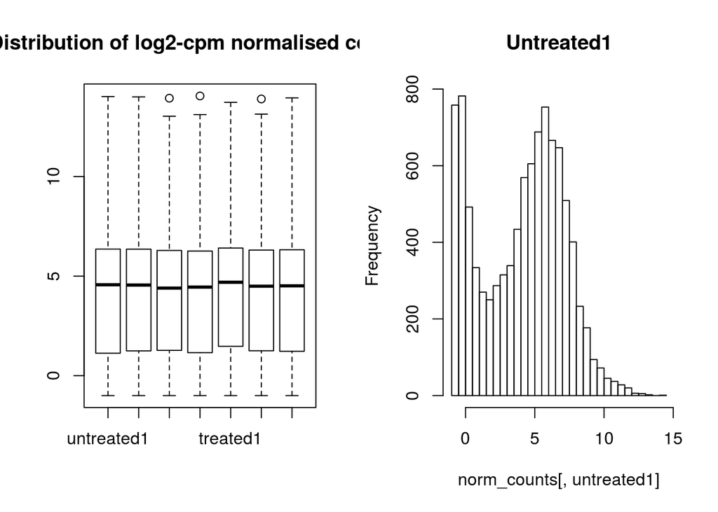

```r
par(mfrow = c(1, 2))
boxplot(norm_counts, main = "Distribution of log2-cpm normalised counts")
hist(norm_counts[, untreated1], breaks = 50, main = "Untreated1")
```

```r
par(mfrow = c(1, 1))
```

As we would expect, the distribution of normalised counts looks the same for each sample - this is good, because it means we can make unbiased comparisons between samples. In addition, the distribution is clearly bimodal, which indicates that some genes are ‘off’ and some are ‘on’. A nice sanity check that all appears to be as it should.

### Exploratory analysis

First, let’s see if there is any obvious differences between our samples (here treated vs. untreated). We will do this by comparing the distance between each sample, based on the normalised expression data.

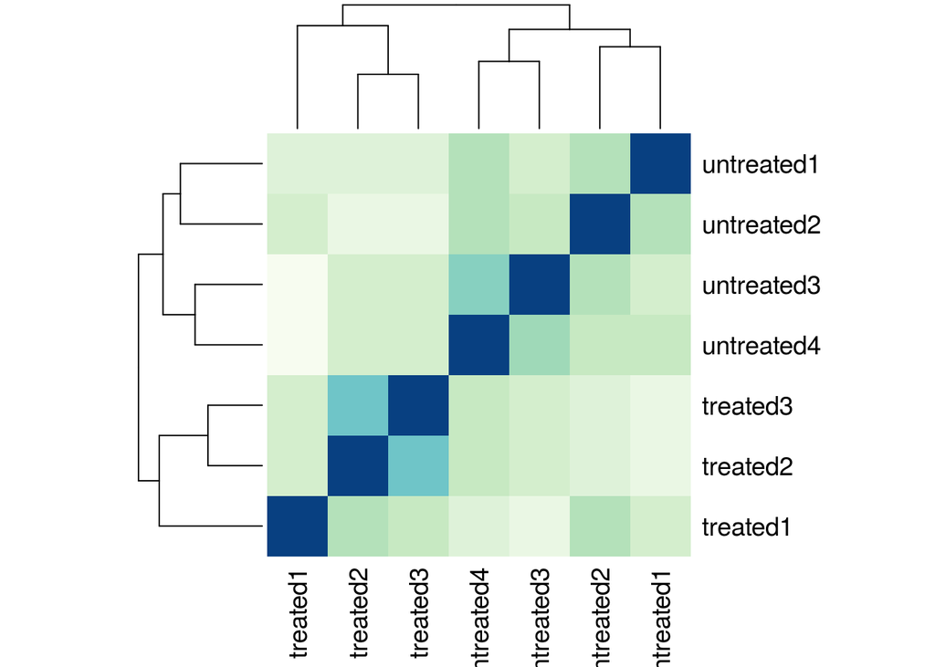

```r
library(RColorBrewer)
hmcol = colorRampPalette(brewer.pal(9, "GnBu"))(16)

by_sample <- t(as.matrix(norm_counts))
heatmap(as.matrix(dist(by_sample)), col = rev(hmcol))
```

There are two obvious groups above: treated vs. untreated. This is what we would expect of course, but it is nice to confirm our hunch. There is something about the gene expression which is different between treated and untreated samples, though we don’t know what. Let’s try to identify these important genes.

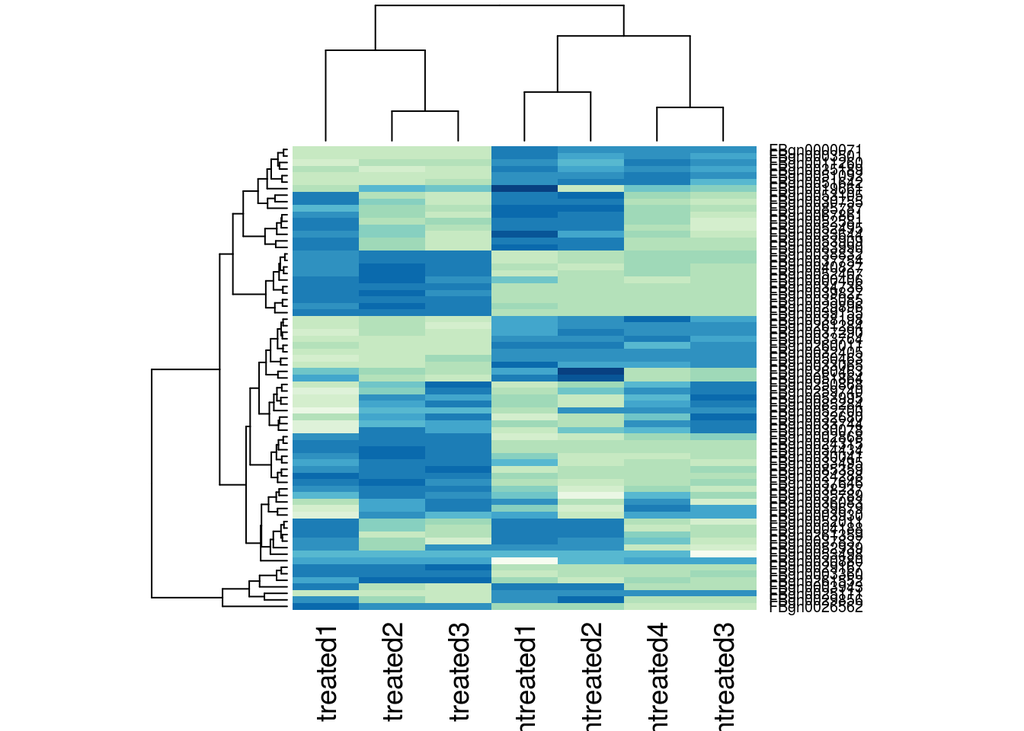

```r
threshold <- 1
high_var_genes <- which(apply(by_sample, 2, sd) > threshold)
colnames(by_sample) <- gene_names

heatmap(t(by_sample[, high_var_genes]), col = rev(hmcol))
```

Clearly, there are some obvious gene clusters which have different levels of expression between the treatment groups. This is great! The choice of threshold is somewhat arbitrary, and here results in only 71 genes. But we would intuitively expect that these 71 genes are those that exhibit the greatest difference in expression between treatment and control. Plenty of great info here to follow up on.

### Differential expression

The heatmap above suggests that there are substantial differences in the gene expression between treated and untreated samples. Differential expression (DE) analysis can give us a more robust statistical test of these differences.

**Caveat:** DE analysis requires replicates to work properly. Here, we have 4 untreated samples and 3 treated samples, so this should work well. In a time-series analysis you would have to have multiple samples measured at each time point to achieve the same effect. DE analysis is hihgly unlikely to yield meaningful results without replicates.

Below, we will use the DESeq2 lirbary to perform DE analysis.

```r
library(DESeq2)
treatment <- data.frame(sample_name = colnames(raw_counts),
                        treatment_group = c("A", "A", "A", "A", "B", "B", "B"))
dds <- DESeqDataSetFromMatrix(countData = raw_counts,
                              colData = treatment,
                              design = ~ treatment_group)
dds <- DESeq(dds)
res <- as.data.table(results(dds))
res[, Gene := gene_names]
res[order(padj, decreasing = FALSE), .(Gene, log2FoldChange, padj)][1:10]
```

```
##            Gene log2FoldChange          padj
##  1: FBgn0039155      -4.107343 9.092151e-182
##  2: FBgn0025111       2.703694 1.157577e-113
##  3: FBgn0029167      -2.108681 1.157577e-113
##  4: FBgn0003360      -2.901219 4.644331e-105
##  5: FBgn0039827      -3.371160  2.700957e-79
##  6: FBgn0035085      -2.360174  3.137019e-77
##  7: FBgn0034736      -2.917021  2.336937e-63
##  8: FBgn0029896      -2.214532  5.221310e-57
##  9: FBgn0000071       2.329336  1.194504e-46
## 10: FBgn0034434      -2.752434  1.764798e-43
```

There is clear evidence for DE between treated and untreated samples. Above, the top 10 differentially expressed genes have been printed. Although we haven’t done so here, if you compare the top 10 - 20 DE genes to the heatmap above you will note that 3 or 4 of the gene clusters are strongly represented in the top 20 DE genes.